# Capítulo 4: Classification

**g)** Carrega a biblioteca “class”, que contém a função para implementar KNN:

```r
library(class)
```

Modelo de KNN com K = 1 com lag2 como única variável independente:

```r
train.X = as.matrix(train$Lag2)
test.X = as.matrix(test$Lag2)
train.Direction = train$Direction
set.seed(1)
Modelo5 = knn(train.X, test.X, train.Direction, k = 1)
table(Modelo5, test$Direction)
```

```
##
## Modelo5 Down Up
##    Down   21 30
##    Up     22 31
```

Percentual de acertos do Modelo 5:

```r
mean(Modelo5 == test$Direction)
```

```
## [1] 0.5
```

O Modelo de KNN com K = 1 acerta exatamento em 50% dos casos. De fato, ele é pior que apenas chutar sempre que haverá subida das ações.

**h)** O Modelo de regressão logística e o Modelo de LDA fornecem a melhor previsão para estes dados, pois são os que apresentam menores taxas de erros no banco de teste.

**11)** **a)** Cria a variável mpg01:

```r
mpg01 = ifelse(Auto$mpg > median(Auto$mpg), 1, 0)
```

Anexa a variável mpg01 ao banco de dados Auto:

```r
Auto = cbind(mpg01, Auto)
```

**b)** Matriz de scatterplots e de correlação:

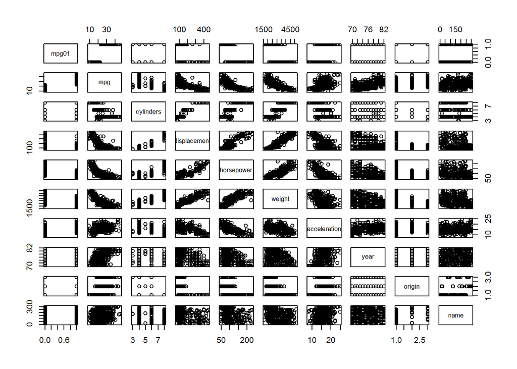

```r
plot(Auto)
```

```r
cor(Auto[,-10])
```

```
##                   mpg01        mpg  cylinders displacement horsepower
## mpg01         1.0000000  0.8369392 -0.7591939   -0.7534766 -0.6670526
## mpg           0.8369392  1.0000000 -0.7776175   -0.8051269 -0.7784268
## cylinders    -0.7591939 -0.7776175  1.0000000    0.9508233  0.8429834
## displacement -0.7534766 -0.8051269  0.9508233    1.0000000  0.8972570
## horsepower   -0.6670526 -0.7784268  0.8429834    0.8972570  1.0000000
## weight       -0.7577566 -0.8322442  0.8975273    0.9329944  0.8645377
## acceleration  0.3468215  0.4233285 -0.5046834   -0.5438005 -0.6891955
## year          0.4299042  0.5805410 -0.3456474   -0.3698552 -0.4163615
## origin        0.5136984  0.5652088 -0.5689316   -0.6145351 -0.4551715
##                  weight acceleration       year     origin
## mpg01        -0.7577566    0.3468215  0.4299042  0.5136984
## mpg          -0.8322442    0.4233285  0.5805410  0.5652088
## cylinders     0.8975273   -0.5046834 -0.3456474 -0.5689316
## displacement  0.9329944   -0.5438005 -0.3698552 -0.6145351
## horsepower    0.8645377   -0.6891955 -0.4163615 -0.4551715
## weight        1.0000000   -0.4168392 -0.3091199 -0.5850054
## acceleration -0.4168392    1.0000000  0.2903161  0.2127458
## year         -0.3091199    0.2903161  1.0000000  0.1815277
## origin       -0.5850054    0.2127458  0.1815277  1.0000000
```

Os scatterplots sugerem que há uma relação entre mpg01 e displacement, horsepower, weight e acceleration. Já a matriz de correlação sugere que a variável cylinders também pode contribui para a explicação de mpg01.

**c)** Divide o banco em train e test.

```r
train = subset(Auto, year %% 2 == 0)
test = subset(Auto, year %% 2 != 0)
```

**d)** Modelo de LDA com as variáveis que pareceram relevantes no item b:

```r
Modelo6 = lda(mpg01 ~ cylinders + displacement + horsepower + weight + acceleration, data = train)
Modelo6
```

```
## Call:
## lda(mpg01 ~ cylinders + displacement + horsepower + weight +
##     acceleration, data = train)
##
## Prior probabilities of groups:
##         0         1
## 0.4571429 0.5428571
##
## Group means:
##   cylinders displacement horsepower   weight acceleration
## 0  6.812500     271.7396  133.14583 3604.823     14.47500
## 1  4.070175     111.6623   77.92105 2314.763     16.62895
##
## Coefficients of linear discriminants:
##                        LD1
## cylinders    -0.6825609783
## displacement  0.0001619815
## horsepower    0.0038925740
## weight       -0.0010554398
## acceleration -0.0273265018
```

Matriz de Confusão do Modelo 6:

```r
Modelo6.pred = predict(Modelo6, test)
table(Modelo6.pred$class, test$mpg01)
```

```
##
##      0  1
##   0 86  8
##   1 14 74
```

Erro de teste do Modelo:

```r
1 - mean(Modelo6.pred$class == test$mpg01)
```

```
## [1] 0.1208791
```

O Modelo apresenta um erro de 12,09%. Um percentual consideravelmente baixo, dado que se fosse utilizada como referência a opção de chutar sempre zero, o resultado esperado seria um acerto em 54,95% das vezes.

**e)** Modelo de QDA com as variáveis que pareceram relevantes no item b:

```r
Modelo7 = qda(mpg01 ~ cylinders + displacement + horsepower + weight + acceleration, data = train)
Modelo7
```

```
## Call:
## qda(mpg01 ~ cylinders + displacement + horsepower + weight +
##     acceleration, data = train)
##
## Prior probabilities of groups:
##         0         1
## 0.4571429 0.5428571
##
## Group means:
##   cylinders displacement horsepower   weight acceleration
## 0  6.812500     271.7396  133.14583 3604.823     14.47500
## 1  4.070175     111.6623   77.92105 2314.763     16.62895
```

Matriz de Confusão do Modelo 7:

```r
Modelo7.pred = predict(Modelo7, test)
table(Modelo7.pred$class, test$mpg01)
```

```
##
##      0  1
##   0 88 12
##   1 12 70
```

Erro de teste do Modelo 7:

```r
1 - mean(Modelo7.pred$class == test$mpg01)
```

```
## [1] 0.1318681
```

O Modelo apresenta um erro de 13,19%. Apesar de o erro ser menor que o do modelo base, ainda assim é maior que o do Modelo 6 (LDA), o que sugere que o Bayes Decision Boundary do fenômeno analisado é linear.

**f)** Modelo de Regressão Logística com as variáveis que pareceram relevantes no item b:

```r
Modelo8 = glm(mpg01 ~ cylinders + displacement + horsepower + weight + acceleration, data = train, family = "binomial")
summary(Modelo8)
```

```
##
## Call:
## glm(formula = mpg01 ~ cylinders + displacement + horsepower +
##     weight + acceleration, family = "binomial", data = train)
##
## Deviance Residuals:
##     Min       1Q   Median       3Q      Max
## -2.6447  -0.0300   0.1093   0.2772   2.4968
##
## Coefficients:
##                Estimate Std. Error z value Pr(>|z|)
## (Intercept)  21.5252507  5.2710952   4.084 4.43e-05 ***
## cylinders    -1.0514731  0.6606828  -1.591   0.1115
## displacement -0.0009795  0.0155812  -0.063   0.9499
## horsepower   -0.0759966  0.0355423  -2.138   0.0325 *
## weight       -0.0018981  0.0014644  -1.296   0.1949
## acceleration -0.2253047  0.2140185  -1.053   0.2925
## ---
## Signif. codes:  0 '***' 0.001 '**' 0.01 '*' 0.05 '.' 0.1 ' ' 1
##
## (Dispersion parameter for binomial family taken to be 1)
##
##     Null deviance: 289.577  on 209  degrees of freedom
## Residual deviance:  82.141  on 204  degrees of freedom
## AIC: 94.141
##
## Number of Fisher Scoring iterations: 8
```

Matriz de confusão do Modelo 8:

```r
Modelo8.probs = predict(Modelo8, test, type = "response")
Modelo8.pred = ifelse(Modelo8.probs > .5, 1, 0)
table(Modelo8.pred, test$mpg01)
```

```
##
## Modelo8.pred  0  1
##            0 89 11
##            1 11 71
```

Erro de teste do Modelo 8:

```r
1 - mean(Modelo8.pred == test$mpg01)
```

```
## [1] 0.1208791
```

O Modelo apresenta um erro de 12,09%. O mesmo apresentado para o Modelo com LDA.

**g)** Modelo de KNN com K = 1 com as variáveis que pareceram relevantes no item b:

```r
train.X = cbind(train$cylinders, train$displacement, train$horsepower, train$weight, train$acceleration)
test.X = cbind(test$cylinders, test$displacement, test$horsepower, test$weight, test$acceleration)
train.Y = train$mpg01
set.seed(1)
Modelo9 = knn(train.X, test.X, train.Y, k = 1)
table(Modelo9, test$mpg01)
```

```
##
## Modelo9  0  1
##       0 83 11
##       1 17 71
```

Erro de teste do Modelo 9:

```r
1 - mean(Modelo9 == test$mpg01)
```

```
## [1] 0.1538462
```

Modelo de KNN com K = 5:

```r
Modelo10 = knn(train.X, test.X, train.Y, k = 5)
table(Modelo10, test$mpg01)
```

```
##
## Modelo10  0  1
##        0 82  9
##        1 18 73
```

Erro de teste do Modelo 10:

```r
1 - mean(Modelo10 == test$mpg01)
```

```
## [1] 0.1483516
```

```r
Modelo11 = knn(train.X, test.X, train.Y, k = 5)
table(Modelo11, test$mpg01)
```

```
##
## Modelo11  0  1
##        0 82  9
##        1 18 73
```

Erro de teste do Modelo 11:

```r
1 - mean(Modelo11 == test$mpg01)
```

```
## [1] 0.1483516
```

**12)** **a)** Resolvida no item b).

**b)** Função Power(x,a) que eleva $x$ ao valor de $a$:

```r
Power = function(x, a) {
  if (a == 0) {
    return(1)
  }
  result = 1
  for(i in 1:a) {
    result = result * x
  }
  print(result)
}
```

Testa a função:

```r
Power(2,0)
```

```
## [1] 1
```

```r
Power(2,3)
```

```
## [1] 8
```

```r
Power(2,10)
```

```
## [1] 1024
```

**c)**

```r
Power(10,3)
```

```
## [1] 1000
```

```r
Power(8,17)
```

```
## [1] 2.2518e+15
```

```r
Power(131,3)
```

```
## [1] 2248091
```

**d)** Alteração de Power para retornar um objeto, ao invés de imprimir os resultados:

```r
Power = function(x, a) {
  if (a == 0) {
    return(1)
  }
  result = 1
  for(i in 1:a) {
    result = result * x
  }
  return(result)
}
```

**e)**

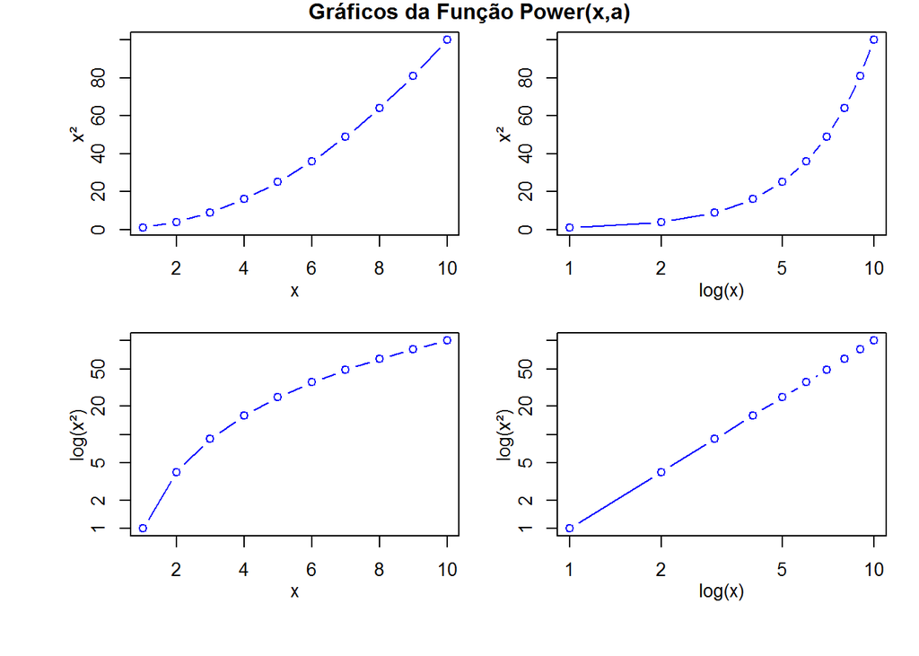

```r
x = 1:10
par(mfrow = c(2,2), mar=c(4,4,0.5,0.5), oma=c(1.5,2,1,1), mgp=c(2,1,0))
plot(Power(x,2) ~ x, ylab = "x²")
lines(Power(x,2) ~ x, type = "b", col = "blue")
plot(Power(x,2) ~ x, log="x", ylab = "x²", xlab="log(x)")
lines(Power(x,2) ~ x, type = "b", col = "blue")
plot(Power(x,2) ~ x, log="y", ylab = "log(x²)")
lines(Power(x,2) ~ x, type = "b", col = "blue")
plot(Power(x,2) ~ x, log="xy", ylab = "log(x²)", xlab="log(x)")
lines(Power(x,2) ~ x, type = "b", col = "blue")
title("Gráficos da Função Power(x,a)", outer = TRUE)
```

**f)**

```r
PlotPower = function(x,a){
  par(mfrow = c(2,2), mar=c(4,4,0.5,0.5), oma=c(1.5,2,1,1), mgp=c(2,1,0))
plot(Power(x,2) ~ x, ylab = paste("x elevado a", a))
lines(Power(x,2) ~ x, type = "b", col = "blue")
plot(Power(x,2) ~ x, log="x", ylab = paste("x elevado a", a), xlab="log(x)")
lines(Power(x,2) ~ x, type = "b", col = "blue")
plot(Power(x,2) ~ x, log="y", ylab = paste("log de x elevado a", a))
lines(Power(x,2) ~ x, type = "b", col = "blue")
plot(Power(x,2) ~ x, log="xy", ylab = paste("log de x elevado a", a), xlab="log(x)")
lines(Power(x,2) ~ x, type = "b", col = "blue")
title(paste("Gráficos de x elevado a", a), outer = TRUE)
}
```

Testa a função:

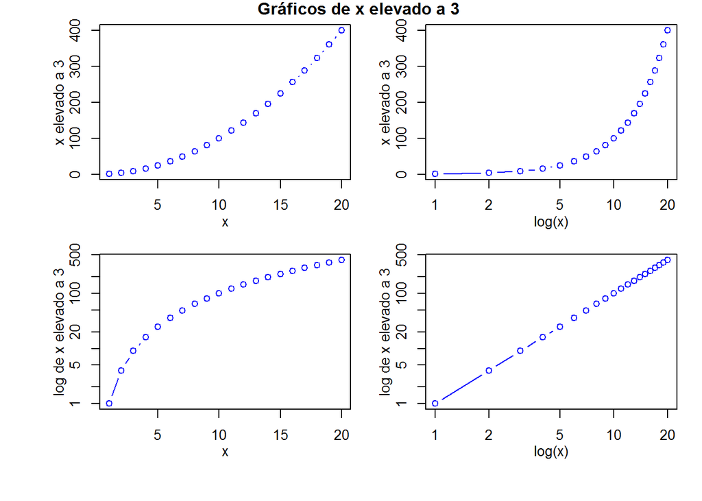

```r
PlotPower(1:20, 3)
```

**13)** Cria a variável mediancrime e a incorpora no banco de Boston:

```r
mediancrime = ifelse(Boston$crim > median(Boston$crim), 1, 0)
Boston = cbind(mediancrime, Boston)
```

Estatísticas básicas do Banco Boston:

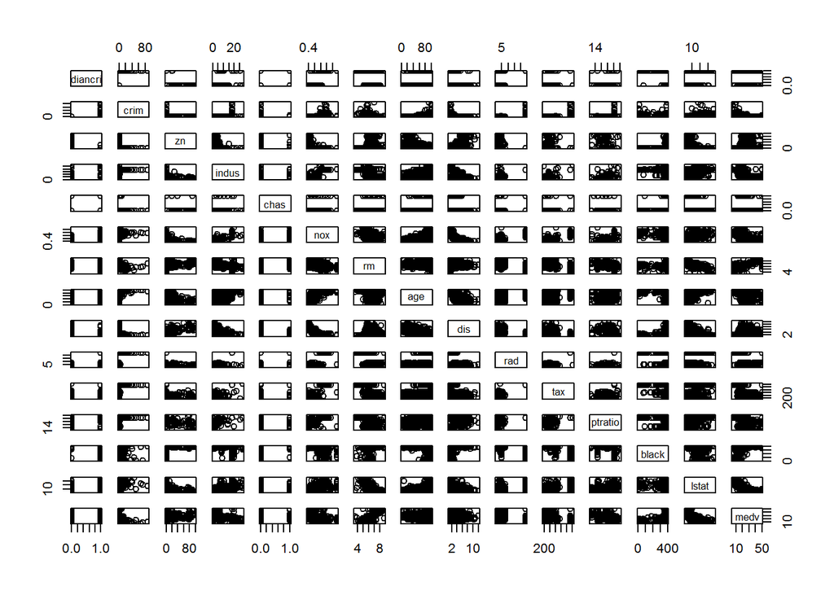

```r
plot(Boston)
```

```r
summary(Boston)
```

```
##   mediancrime       crim                zn             indus
##  Min.   :0.0   Min.   : 0.00632   Min.   :  0.00   Min.   : 0.46
##  1st Qu.:0.0   1st Qu.: 0.08204   1st Qu.:  0.00   1st Qu.: 5.19
##  Median :0.5   Median : 0.25651   Median :  0.00   Median : 9.69
##  Mean   :0.5   Mean   : 3.61352   Mean   : 11.36   Mean   :11.14
##  3rd Qu.:1.0   3rd Qu.: 3.67708   3rd Qu.: 12.50   3rd Qu.:18.10
##  Max.   :1.0   Max.   :88.97620   Max.   :100.00   Max.   :27.74
##       chas              nox               rm             age
##  Min.   :0.00000   Min.   :0.3850   Min.   :3.561   Min.   :  2.90
##  1st Qu.:0.00000   1st Qu.:0.4490   1st Qu.:5.886   1st Qu.: 45.02
##  Median :0.00000   Median :0.5380   Median :6.208   Median : 77.50
##  Mean   :0.06917   Mean   :0.5547   Mean   :6.285   Mean   : 68.57
##  3rd Qu.:0.00000   3rd Qu.:0.6240   3rd Qu.:6.623   3rd Qu.: 94.08
##  Max.   :1.00000   Max.   :0.8710   Max.   :8.780   Max.   :100.00
##       dis              rad              tax           ptratio
##  Min.   : 1.130   Min.   : 1.000   Min.   :187.0   Min.   :12.60
##  1st Qu.: 2.100   1st Qu.: 4.000   1st Qu.:279.0   1st Qu.:17.40
##  Median : 3.207   Median : 5.000   Median :330.0   Median :19.05
##  Mean   : 3.795   Mean   : 9.549   Mean   :408.2   Mean   :18.46
##  3rd Qu.: 5.188   3rd Qu.:24.000   3rd Qu.:666.0   3rd Qu.:20.20
##  Max.   :12.127   Max.   :24.000   Max.   :711.0   Max.   :22.00
##      black            lstat            medv
##  Min.   :  0.32   Min.   : 1.73   Min.   : 5.00
##  1st Qu.:375.38   1st Qu.: 6.95   1st Qu.:17.02
##  Median :391.44   Median :11.36   Median :21.20
##  Mean   :356.67   Mean   :12.65   Mean   :22.53
##  3rd Qu.:396.23   3rd Qu.:16.95   3rd Qu.:25.00
##  Max.   :396.90   Max.   :37.97   Max.   :50.00
```

```r
cor(Boston)
```

```
##             mediancrime        crim          zn       indus         chas
## mediancrime  1.00000000  0.40939545 -0.43615103  0.60326017  0.070096774
## crim         0.40939545  1.00000000 -0.20046922  0.40658341 -0.055891582
## zn          -0.43615103 -0.20046922  1.00000000 -0.53382819 -0.042696719
## indus        0.60326017  0.40658341 -0.53382819  1.00000000  0.062938027
## chas         0.07009677 -0.05589158 -0.04269672  0.06293803  1.000000000
## nox          0.72323480  0.42097171 -0.51660371  0.76365145  0.091202807
## rm          -0.15637178 -0.21924670  0.31199059 -0.39167585  0.091251225
## age          0.61393992  0.35273425 -0.56953734  0.64477851  0.086517774
## dis         -0.61634164 -0.37967009  0.66440822 -0.70802699 -0.099175780
## rad          0.61978625  0.62550515 -0.31194783  0.59512927 -0.007368241
## tax          0.60874128  0.58276431 -0.31456332  0.72076018 -0.035586518
## ptratio      0.25356836  0.28994558 -0.39167855  0.38324756 -0.121515174
## black       -0.35121093 -0.38506394  0.17552032 -0.35697654  0.048788485
## lstat        0.45326273  0.45562148 -0.41299457  0.60379972 -0.053929298
## medv        -0.26301673 -0.38830461  0.36044534 -0.48372516  0.175260177
##                     nox          rm         age         dis          rad
## mediancrime  0.72323480 -0.15637178  0.61393992 -0.61634164  0.619786249
## crim         0.42097171 -0.21924670  0.35273425 -0.37967009  0.625505145
## zn          -0.51660371  0.31199059 -0.56953734  0.66440822 -0.311947826
## indus        0.76365145 -0.39167585  0.64477851 -0.70802699  0.595129275
## chas         0.09120281  0.09125123  0.08651777 -0.09917578 -0.007368241
## nox          1.00000000 -0.30218819  0.73147010 -0.76923011  0.611440563
## rm          -0.30218819  1.00000000 -0.24026493  0.20524621 -0.209846668
## age          0.73147010 -0.24026493  1.00000000 -0.74788054  0.456022452
## dis         -0.76923011  0.20524621 -0.74788054  1.00000000 -0.494587930
## rad          0.61144056 -0.20984667  0.45602245 -0.49458793  1.000000000
## tax          0.66802320 -0.29204783  0.50645559 -0.53443158  0.910228189
## ptratio      0.18893268 -0.35550149  0.26151501 -0.23247054  0.464741179
## black       -0.38005064  0.12806864 -0.27353398  0.29151167 -0.444412816
## lstat        0.59087892 -0.61380827  0.60233853 -0.49699583  0.488676335
## medv        -0.42732077  0.69535995 -0.37695457  0.24992873 -0.381626231
##                     tax    ptratio       black      lstat       medv
## mediancrime  0.60874128  0.2535684 -0.35121093  0.4532627 -0.2630167
## crim         0.58276431  0.2899456 -0.38506394  0.4556215 -0.3883046
## zn          -0.31456332 -0.3916785  0.17552032 -0.4129946  0.3604453
## indus        0.72076018  0.3832476 -0.35697654  0.6037997 -0.4837252
## chas        -0.03558652 -0.1215152  0.04878848 -0.0539293  0.1752602
## nox          0.66802320  0.1889327 -0.38005064  0.5908789 -0.4273208
## rm          -0.29204783 -0.3555015  0.12806864 -0.6138083  0.6953599
## age          0.50645559  0.2615150 -0.27353398  0.6023385 -0.3769546
## dis         -0.53443158 -0.2324705  0.29151167 -0.4969958  0.2499287
## rad          0.91022819  0.4647412 -0.44441282  0.4886763 -0.3816262
## tax          1.00000000  0.4608530 -0.44180801  0.5439934 -0.4685359
## ptratio      0.46085304  1.0000000 -0.17738330  0.3740443 -0.5077867
## black       -0.44180801 -0.1773833  1.00000000 -0.3660869  0.3334608
## lstat        0.54399341  0.3740443 -0.36608690  1.0000000 -0.7376627
## medv        -0.46853593 -0.5077867  0.33346082 -0.7376627  1.0000000
```

Por estas estatísticas e gráficos, vemos que as variáveis que parecem estar mais fortemente correlacionadas à mediana de crimes nos subúrbios são indus, nox, age, dis, rad e tax. Estas serão as variáveis utilizadas nos modelos para prever a mediana de crimes ocorridos nos modelos que serão apresentados a seguir.  
Divide o banco em train e test:

```r
train = Boston[1:253,]
test = Boston[254:506,]
```

**Modelo de Regressão Logística**

```r
Logistica = glm(mediancrime ~ indus + nox + age + dis + rad + tax, data = Boston, family = "binomial")
summary(Logistica)
```

```
##
## Call:
## glm(formula = mediancrime ~ indus + nox + age + dis + rad + tax,
##     family = "binomial", data = Boston)
##
## Deviance Residuals:
##      Min        1Q    Median        3Q       Max
## -2.03125  -0.27008  -0.01357   0.00652   2.73140
##
## Coefficients:
##               Estimate Std. Error z value Pr(>|z|)
## (Intercept) -24.507204   3.744238  -6.545 5.94e-11 ***
## indus        -0.057598   0.042350  -1.360  0.17381
## nox          42.093845   6.918888   6.084 1.17e-09 ***
## age           0.013831   0.008743   1.582  0.11365
## dis           0.206086   0.146095   1.411  0.15835
## rad           0.598177   0.115935   5.160 2.47e-07 ***
## tax          -0.007260   0.002363  -3.072  0.00213 **
## ---
## Signif. codes:  0 '***' 0.001 '**' 0.01 '*' 0.05 '.' 0.1 ' ' 1
##
## (Dispersion parameter for binomial family taken to be 1)
##
##     Null deviance: 701.46  on 505  degrees of freedom
## Residual deviance: 244.77  on 499  degrees of freedom
## AIC: 258.77
##
## Number of Fisher Scoring iterations: 8
```

Matriz de Confusão da Regressão Logística:

```r
Logistica.probs = predict(Logistica, test, type = "response")
Logistica.pred = ifelse(Logistica.probs > .5, 1, 0)
table(Logistica.pred, test$mediancrime)
```

```
##
## Logistica.pred   0   1
##              0  81  16
##              1   9 147
```

Erro de teste da Regressão Logística:

```r
1 - mean(Logistica.pred == test$mediancrime)
```

```
## [1] 0.09881423
```

**Linear Discriminant Analysis**

```r
LDA = lda(mediancrime ~ indus + nox + age + dis + rad + tax, data = Boston)
LDA
```

```
## Call:
## lda(mediancrime ~ indus + nox + age + dis + rad + tax, data = Boston)
##
## Prior probabilities of groups:
##   0   1
## 0.5 0.5
##
## Group means:
##       indus       nox      age      dis       rad      tax
## 0  7.002292 0.4709711 51.31028 5.091596  4.158103 305.7431
## 1 15.271265 0.6384190 85.83953 2.498489 14.940711 510.7312
##
## Coefficients of linear discriminants:
##                LD1
## indus  0.008065512
## nox    7.126686821
## age    0.011163382
## dis   -0.051089244
## rad    0.090266195
## tax   -0.001698893
```

Matriz de Confusão da LDA:

```r
LDA.pred = predict(LDA, test)
table(LDA.pred$class, test$mediancrime)
```

```
##
##       0   1
##   0  88  20
##   1   2 143
```

Erro de teste da LDA:

```r
1 - mean(LDA.pred$class == test$mediancrime)
```

```
## [1] 0.08695652
```

**Quadratic Discriminant Analysis**

```r
QDA = qda(mediancrime ~ indus + nox + age + dis + rad + tax, data = Boston)
QDA
```

```
## Call:
## qda(mediancrime ~ indus + nox + age + dis + rad + tax, data = Boston)
##
## Prior probabilities of groups:
##   0   1
## 0.5 0.5
##
## Group means:
##       indus       nox      age      dis       rad      tax
## 0  7.002292 0.4709711 51.31028 5.091596  4.158103 305.7431
## 1 15.271265 0.6384190 85.83953 2.498489 14.940711 510.7312
```

Matriz de Confusão da QDA:

```r
QDA.pred = predict(QDA, test)
table(QDA.pred$class, test$mediancrime)
```

```
##
##       0   1
##   0  83  12
##   1   7 151
```

Erro de teste da QDA:

```r
1 - mean(QDA.pred$class == test$mediancrime)
```

```
## [1] 0.07509881
```

**KNN**  
**K = 1**

```r
train.X = cbind(train$indus, train$nox, train$age, train$dis, train$rad, train$tax)
test.X = cbind(test$indus, test$nox, test$age, test$dis, test$rad, test$tax)
train.Y = train$mediancrime
set.seed(1)
KNN1 = knn(train.X, test.X, train.Y, k = 1)
table(KNN1, test$mediancrime)
```

```
##
## KNN1   0   1
##    0  82 151
##    1   8  12
```

Erro de teste de KNN para K = 1:

```r
1 - mean(KNN1 == test$mediancrime)
```

```
## [1] 0.6284585
```

**K = 5**

```r
set.seed(1)
KNN5 = knn(train.X, test.X, train.Y, k = 5)
table(KNN5, test$mediancrime)
```

```
##
## KNN5   0   1
##    0  80  22
##    1  10 141
```

Erro de teste de KNN para K = 5:

```r
1 - mean(KNN5 == test$mediancrime)
```

```
## [1] 0.1264822
```

**K = 10**

```r
set.seed(1)
KNN10 = knn(train.X, test.X, train.Y, k = 10)
table(KNN10, test$mediancrime)
```

```
##
## KNN10   0   1
##     0  83  23
##     1   7 140
```

Erro de teste de KNN para K = 10:

```r
1 - mean(KNN10 == test$mediancrime)
```

```
## [1] 0.1185771
```

**K = 25**

```r
set.seed(1)
KNN25 = knn(train.X, test.X, train.Y, k = 25)
table(KNN25, test$mediancrime)
```

```
##
## KNN25   0   1
##     0  81  22
##     1   9 141
```

Erro de teste de KNN para K = 25:

```r
1 - mean(KNN25 == test$mediancrime)
```

```
## [1] 0.1225296
```

**K = 50**

```r
set.seed(1)
KNN50 = knn(train.X, test.X, train.Y, k = 50)
table(KNN50, test$mediancrime)
```

```
##
## KNN50   0   1
##     0  79  22
##     1  11 141
```

Erro de teste de KNN para K = 50:

```r
1 - mean(KNN50 == test$mediancrime)
```

```
## [1] 0.1304348
```

**K = 100**

```r
set.seed(1)
KNN100 = knn(train.X, test.X, train.Y, k = 100)
table(KNN100, test$mediancrime)
```

```
##
## KNN100   0   1
##      0  90 163
##      1   0   0
```

Erro de teste de KNN para K = 100:

```r
1 - mean(KNN100 == test$mediancrime)
```

```
## [1] 0.6442688
```

Os resultados observados mostram que o melhor modelo para estes dados é o modelo de Quadratic Discriminant Analysis. Os Modelos de KNN não parecem muito bons, pois os melhores resultados obtidos com KNN ainda são piores que todos os demais resultados obtidos.  
QDA fornecer o melhor modelo de regressão nos sugere que o Bayes Decision Boundary do fenômeno analisado não é linear.